# Regression

Pedro Antonio Benito Rojano

2022-06-10

# Regression

## Libraries

Library for R Markdown.

```r
library(rmarkdown)
```

Library for data frames processing.

```r
library(dplyr)
```

Library for read dataset.

```r
library(readr)
```

Library for summary statistics.

```r
library(skimr)
```

Library for plot.

```r
library(ggplot2)
```

Library for regression.

```r
library(performance)
```

Library for manage strings.

```r
library(stringr)
```

Library for data presentation.

```r
library(scales)
```

## Load dataset

Set paths.

```r
path <- "data/clustering.csv"
```

```r
virusTotal <- read_csv(path)
```

## Preprocessing

### View dataset

```r
virusTotal %>% paged_table()
```

| ...1 | n | size | community_reputation | harmless_votes | malicious_votes | positives | scans.Fortinet.result | submission.filename | submission.submitter_country | submission.submitter_region | times_submitted | total | total_PERMs | unique_sources | additional_info.androguard.AndroidApplication | additional_info.androguard.AndroidVersionCode | additional_info.androguard.AndroidVersionName | additional_info.androguard.certificate.Subject.C | additional_info.androguard.certificate.Subject.CN | additional_info.androguard.certificate.Subject.email | additional_info.androguard.certificate.Subject.L | additional_info.androguard.certificate.Subject.O | additional_info.androguard.certificate.Subject.OU | additional_info.androguard.certificate.Subject.ST | additional_info.androguard.MinSdkVersion | additional_info.androguard.RiskIndicator.APK.SHARED.LIBRARIES | additional_info.androguard.RiskIndicator.PERM.APPOP | additional_info.androguard.RiskIndicator.PERM.DANGEROUS | additional_info.androguard.RiskIndicator.PERM.DEVELOPMENT | … |
| --- | --- | --- | --- | --- | --- | --- | --- | --- | --- | --- | --- | --- | --- | --- | --- | --- | --- | --- | --- | --- | --- | --- | --- | --- | --- | --- | --- | --- | --- | --- |
| 1 | 1 | 1956125 | 0 | 0 | 0 | 20 | Android/Agent.HVN!tr | /vdepot/apk/42/29/42290A1DDB41166F7E8C7536B409F4E6 | US | ca | 1 | 61 | 6 | 1 | 1 | 101 | 23.5.3 | NA | NA | NA | NA | NA | NA | FI | 16 | 0 | 0 | 2 | 0 | … |
| 2 | 2 | 2667641 | 0 | 0 | 0 | 20 | Android/Erwind.A!tr | 398e6e8146d61470c4699f28f168188d.virus | CA | on | 1 | 61 | 10 | 1 | 1 | 9 | 0.8.6 | NL | Jina Gasilov | android@android.com | You Bet | Vandervort-D'Amore | Android | California | 14 | 0 | 0 | 4 | 0 | … |
| 3 | 3 | 3998656 | 0 | 0 | 0 | 18 | Android/Agent.IMA!tr | 07d00b70d7f6.zip | UA | 63 | 1 | 61 | 22 | 1 | 1 | 1 | 1.5 | US | Android | android@android.com | Mountain View | Android | Android | California | 24 | 0 | 0 | 1 | 0 | … |
| 4 | 4 | 500276 | -34 | 18 | 13 | 26 | Android/Generic.S.64F1!tr | WiFiKill-me.paranoid.wifikill-2032-v2.3.2.apk | IE | d | 263 | 64 | 4 | 514 | 1 | 2032 | 2.3.2 | NA | MessyBinary | NA | NA | NA | NA | NA | 14 | 3 | 0 | 0 | 0 | … |
| 5 | 5 | 1956125 | 0 | 0 | 0 | 20 | Android/Agent.HVN!tr | /vdepot/apk/CD/74/CD74C3D8DE98A8F238BB9D6735380404 | US | ca | 1 | 62 | 6 | 1 | 1 | 101 | 23.5.3 | NA | NA | NA | NA | NA | NA | FI | 16 | 0 | 0 | 2 | 0 | … |
| 6 | 6 | 4137920 | 0 | 0 | 0 | 18 | Android/Agent.IVA!tr | ff6f1dd413e4.zip | UA | 63 | 1 | 61 | 22 | 1 | 1 | 1 | 1.5 | US | Android | android@android.com | Mountain View | Android | Android | California | 24 | 0 | 0 | 1 | 0 | … |
| 7 | 7 | 3031864 | 0 | 0 | 0 | 15 | Riskware/Generic.Z.1114DCE!Android | b8456ae6435a76bc7713734f7d273a50.virobj | UA | 30 | 2 | 61 | 0 | 2 | 0 | NA | NA | NA | NA | NA | NA | NA | NA | NA | NA | 0 | 0 | 0 | 0 | … |
| 8 | 8 | 2669106 | 0 | 0 | 0 | 20 | Android/Erwind.A!tr | 511a4359f936ffc8419ff53c97a1af2c.virus | CA | on | 1 | 60 | 10 | 1 | 1 | 9 | 0.8.6 | NL | Jina Gasilov | android@android.com | You Bet | Vandervort-D'Amore | Android | California | 14 | 0 | 0 | 4 | 0 | … |
| 9 | 9 | 2669106 | 0 | 0 | 0 | 21 | Android/Erwind.A!tr | ed89d9884a455e4d9534785edbfe4824.virus | CA | on | 1 | 60 | 10 | 1 | 1 | 9 | 0.8.6 | NL | Jina Gasilov | android@android.com | You Bet | Vandervort-D'Amore | Android | California | 14 | 0 | 0 | 4 | 0 | … |
| 10 | 10 | 5884 | 0 | 0 | 0 | 25 | Android/Shedun.AC!tr | /home/farm/anteroom/0b9/111/0b911143341c6fd040b785df145f64b6a0a3751d55acb0c990f6c326ae7690fa | CZ | jm | 4 | 60 | 0 | 2 | 2 | NA | NA | NA | NA | NA | NA | NA | NA | NA | NA | 0 | 0 | 0 | 0 | … |

[output cut: 173 more lines]

### Remove row number columns

As can be seen, at read the col …1 is added, but the column n already has this information.

```r
df <-
  virusTotal %>%
  select(-...1, -n)
```

### Cast logical columns as numeric

Logical columns can be casted as numeric, TRUE as 1, FALSE as 0.

But 0s are not suitable for regression, so let’s replace FALSE for -1 instead.

```r
replace_value <-
  function(v, value, replacement){
    v[v==value] <- replacement
    return(v)
  }
```

```r
df <-
  df %>%
  mutate_if(
    is.logical,
    function(logical) replace_value(as.numeric(logical), 0, -1))
```

### Select numeric columns

Only numeric columns are suitable for clustering, so just remove them.

```r
df <-
  df %>%
  select_if(is.numeric)
```

### Rows with NA

```r
rows_with_na <-
  function(df){
      df %>%
      is.na() %>%
      rowSums() %>%
      sapply(function(x) x > 0) %>%
      which()
  }
```

```r
nrows_with_na <-
  df %>%
  rows_with_na() %>%
  length()

nrows_with_na / nrow(df)
```

```
## [1] 0.863388
```

Most of the rows of the dataframe has NA so can’t be deleted. If rows with NA were deleted most of the information will be loss.

### Replace NA

Clustering do not work with NAs because distance measure is needed. So just replace NA for predicted value using lineal model.

```r
remove_0 <-
  function(x) x[x!=0]
```

```r
num_of_NA_by_column <-
  function(df){
    df %>% is.na() %>% colSums()
  }
```

```r
names_of_colums_with_NA <-
  function(df)
    df %>%
      num_of_NA_by_column() %>%
      remove_0 %>%
      names()
```

```r
lm_from_all_columns <-
  function(df, column){
    target_column_name <-
      colnames(df)[column]
    col <- df[,column]
    df <-
      df %>%
      select(., -all_of(names_of_colums_with_NA(.))) %>%
      cbind(col)
    formula_lm <-
      paste(target_column_name, ".", sep = " ~ ") %>%
      as.formula()
    lm(formula_lm, data = df, na.action = na.omit)
  }
```

```r
replace_NA_by_predicted_col <-
  function(df, col_index){
    col <-
      df[, col_index] %>%
      unlist()
    has_na <-
      col %>%
      anyNA()
    if(has_na){
      lm_col <-
        lm_from_all_columns(df, col_index)
      col_predicted <-
        predict.lm(lm_col, df) %>%
        as.double()
      na_col <-
        col %>%
        sapply(is.na) %>%
        as.vector()
      col <-
        if_else(na_col, col_predicted, col)
    }
    col <-
      as.vector(col)
    return(col)
  }
```

```r
replace_NA_by_predicted <-
  function(df){
    for(index in 1:ncol(df)){
      df[,index] <- replace_NA_by_predicted_col(df, index)
    }
    return(df)
  }
```

```r
df <-
  replace_NA_by_predicted(df)
```

### View result

```r
df %>%
  paged_table()
```

| size | community_reputation | harmless_votes | malicious_votes | positives | times_submitted | total | total_PERMs | unique_sources | additional_info.androguard.AndroidApplication | additional_info.androguard.AndroidVersionCode | additional_info.androguard.MinSdkVersion | additional_info.androguard.RiskIndicator.APK.SHARED.LIBRARIES | additional_info.androguard.RiskIndicator.PERM.APPOP | additional_info.androguard.RiskIndicator.PERM.DANGEROUS | additional_info.androguard.RiskIndicator.PERM.DEVELOPMENT | additional_info.androguard.RiskIndicator.PERM.EPHEMERAL | additional_info.androguard.RiskIndicator.PERM.GPS | additional_info.androguard.RiskIndicator.PERM.INSTANT | additional_info.androguard.RiskIndicator.PERM.MONEY | additional_info.androguard.RiskIndicator.PERM.NORMAL | additional_info.androguard.RiskIndicator.PERM.PRE23 | additional_info.androguard.RiskIndicator.PERM.PREINSTALLED | additional_info.androguard.RiskIndicator.PERM.PRIVACY | additional_info.androguard.RiskIndicator.PERM.SIGNATURE | additional_info.androguard.RiskIndicator.PERM.SMS | additional_info.androguard.RiskIndicator.PERM.SYSTEM | additional_info.androguard.TargetSdkVersion | additional_info.compressedview.file_types.DEX | additional_info.compressedview.file_types.ELF | … |
| --- | --- | --- | --- | --- | --- | --- | --- | --- | --- | --- | --- | --- | --- | --- | --- | --- | --- | --- | --- | --- | --- | --- | --- | --- | --- | --- | --- | --- | --- | --- |
| 1956125 | 0 | 0 | 0 | 20 | 1 | 61 | 6 | 1 | 1 | 1.010000e+02 | 16.00000 | 0 | 0 | 2 | 0 | 0 | 1 | 0 | 0 | 2 | 0 | 0 | 1 | 0 | 0 | 0 | 2.200000e+01 | 1 | 0 | … |
| 2667641 | 0 | 0 | 0 | 20 | 1 | 61 | 10 | 1 | 1 | 9.000000e+00 | 14.00000 | 0 | 0 | 4 | 0 | 0 | 0 | 0 | 0 | 5 | 0 | 0 | 1 | 0 | 0 | 0 | 2.200000e+01 | 3 | 0 | … |
| 3998656 | 0 | 0 | 0 | 18 | 1 | 61 | 22 | 1 | 1 | 1.000000e+00 | 24.00000 | 0 | 0 | 1 | 0 | 0 | 0 | 4 | 2 | 7 | 0 | 0 | 4 | 0 | 4 | 0 | 2.800000e+01 | 0 | 0 | … |
| 500276 | -34 | 18 | 13 | 26 | 263 | 64 | 4 | 514 | 1 | 2.032000e+03 | 14.00000 | 3 | 0 | 0 | 0 | 0 | 0 | 0 | 0 | 4 | 0 | 0 | 0 | 0 | 0 | 0 | 1.700000e+01 | 1 | 3 | … |
| 1956125 | 0 | 0 | 0 | 20 | 1 | 62 | 6 | 1 | 1 | 1.010000e+02 | 16.00000 | 0 | 0 | 2 | 0 | 0 | 1 | 0 | 0 | 2 | 0 | 0 | 1 | 0 | 0 | 0 | 2.200000e+01 | 1 | 0 | … |
| 4137920 | 0 | 0 | 0 | 18 | 1 | 61 | 22 | 1 | 1 | 1.000000e+00 | 24.00000 | 0 | 0 | 1 | 0 | 0 | 0 | 4 | 2 | 7 | 0 | 0 | 4 | 0 | 4 | 0 | 2.800000e+01 | 0 | 0 | … |
| 3031864 | 0 | 0 | 0 | 15 | 2 | 61 | 0 | 2 | 0 | -1.859510e+00 | 14.04221 | 0 | 0 | 0 | 0 | 0 | 0 | 0 | 0 | 0 | 0 | 0 | 0 | 0 | 0 | 0 | 1.629037e+01 | 0 | 0 | … |
| 2669106 | 0 | 0 | 0 | 20 | 1 | 60 | 10 | 1 | 1 | 9.000000e+00 | 14.00000 | 0 | 0 | 4 | 0 | 0 | 0 | 0 | 0 | 5 | 0 | 0 | 1 | 0 | 0 | 0 | 2.200000e+01 | 3 | 0 | … |
| 2669106 | 0 | 0 | 0 | 21 | 1 | 60 | 10 | 1 | 1 | 9.000000e+00 | 14.00000 | 0 | 0 | 4 | 0 | 0 | 0 | 0 | 0 | 5 | 0 | 0 | 1 | 0 | 0 | 0 | 2.200000e+01 | 3 | 0 | … |
| 5884 | 0 | 0 | 0 | 25 | 4 | 60 | 0 | 2 | 2 | -1.063259e+06 | 2971.33938 | 0 | 0 | 0 | 0 | 0 | 0 | 0 | 0 | 0 | 0 | 0 | 0 | 0 | 0 | 0 | 7.288239e+03 | 0 | 0 | … |

[output cut: 173 more lines]

## Regression

The idea is to get the best models to predict the most important variables of the dataset.

How to get the best model?

1. Compute all one variable models for target
2. Sort them by R2-ajusted
3. Iteratively while R2-adjusted does not get worse:
- Add the best predicted variable remaining from the sorted list to the lineal model.
- Check if there are useless variables to remove. Called as useless those predictors whose p-value is over 0.05.
- Remove useless if is necessary.
- Compute R2-adjusted.

This method compute the best model?

No, it’s no the best model, but it’s a good approach to get a good enough model without much computing.

### Important columns

```r
important_columns_logical <-
  df %>%
  colnames() %>%
  str_detect("n|\\.", negate = TRUE)
```

```r
important_columns_index <-
  important_columns_logical %>%
  which()
```

```r
important_columns_names <-
  colnames(df)[important_columns_index]
important_columns_names
```

```
## [1] "size"            "harmless_votes"  "malicious_votes" "positives"
## [5] "times_submitted" "total"           "total_PERMs"
```

### Define functions

```r
formula_from_names <-
  function(target, col){
    formulaStr <- paste0(target, "~", col)
    formula <- as.formula(formulaStr)
  }
```

```r
lm_from_names <-
  function(df, target, col)
    lm(formula_from_names(target, col), data = df)
```

```r
all_one_variable_models <- function(df, target){
  names <- colnames(df)
  names <- names[names!=target]
  lapply(names, function(col) lm_from_names(df, target, col))
}
```

```r
get_r2_adjusted <-
  function(lm)
    r2(lm)[[2]]
```

```r
get_pvalues <-
  function(lm, intercept = TRUE){
    coefs_df <-
      lm %>%
      summary() %>%
      coef() %>%
      as.data.frame()
    pvales <-
      coefs_df$`Pr(>|t|)`
    names(pvales) <-
      coefs_df %>%
      rownames() %>%
      str_replace(fixed("(Intercept)"), "1")
    if(!intercept){
      pvales <-
        pvales[2:length(pvales)]
    }
    return(pvales)
  }
```

```r
sort_models <- function(models){
  models_r2 <-
    models %>%
    sapply(get_r2_adjusted)
  models_df <-
    tibble(model = models, r2 = models_r2) %>%
    arrange(desc(r2)) %>%
    pull("model")
}
```

```r
rank_one_variable_models <-
  function(df, target){
    rank <-
      df %>%
      all_one_variable_models(target) %>%
      sort_models
    return(rank)
  }
```

```r
get_target_name <-
  function(lm){
    lm_terms <-
      lm_test %>%
      summary() %>%
      terms()
    predicted <-
      lm_terms[[2]] %>%
      as.character()
    return(predicted)
  }
```

```r
get_predictors_names <-
  function(lm){
    lm_terms <-
      lm %>%
      summary() %>%
      terms()
    predictors_str <-
      lm_terms[[3]]
    predictors <-
      predictors_str %>%
      as.character() %>%
      str_remove_all("\\+|\\-|-[:blank:]1") %>%
      str_split(fixed(" ")) %>%
      unlist()
    predictors <-
      predictors[predictors != ""]
    return(predictors)
  }
```

```r
lm_from_names <-
  function(df, target, predictors, intercept = TRUE){
    predictors_str <-
      paste(predictors, collapse = " + ")
    formula_str <-
      paste(target, predictors_str, sep = " ~ ")
    if(!intercept){
      formula_str <-
        paste(formula_str, "1", sep = " - ")
    }
    formula <-
      formula_str %>%
      as.formula()
    lm <-
      lm(formula, data = df)
  }
```

```r
best_model <-
  function(df, target){
    predictors_rank <-
      rank_one_variable_models(df, target) %>%
      sapply(get_predictors_names)
    idx <- 1
    r2_adjusted_prev <- -Inf
    r2_adjusted_current <- 0
    lm_current <- NA
    while(r2_adjusted_current >= r2_adjusted_prev){
      lm_current <-
        lm_from_names(df, target, predictors_rank[1:idx])
      pvalues <-
        get_pvalues(lm_current, FALSE)
      useless <-
        pvalues[pvalues > 0.05] %>%
        names()
      predictors_rank <-
        predictors_rank[!(predictors_rank %in% useless)]
      idx <- idx - length(useless)
      lm_current <-
        lm_from_names(df, target, predictors_rank[1:idx])
      r2_adjusted_prev <-
        r2_adjusted_current
      r2_adjusted_current <-
        get_r2_adjusted(lm_current)
      idx <- idx + 1
    }
    return(lm_current)
  }
```

```r
best_models <-
  function(df, targets){
    best_models <-
      targets %>%
      lapply(function(target) best_model(df, target))
    return(best_models)
  }
```

### Compute best lineal models

Compute best models for important variables.

```r
best_models_main_variables <-
  best_models(df, important_columns_names)
```

## View results

### R2-adjusted

Calc R2-adjusted.

```r
best_models_r2 <-
  best_models_main_variables %>%
  sapply(get_r2_adjusted)
names(best_models_r2) <-
  important_columns_names
```

```r
best_models_r2 %>%
  sort(decreasing = TRUE)
```

```
##  harmless_votes malicious_votes     total_PERMs            size           total
##       0.9990731       0.9942802       0.9816816       0.6683957       0.3840575
##       positives times_submitted
##       0.3141946       0.1166208
```

### Summary

```r
best_models_summary <-
  best_models_main_variables %>%
  lapply(summary)
names(best_models_summary) <-
  important_columns_names
```

```r
best_models_summary$harmless_votes
```

```
##
## Call:
## lm(formula = formula, data = df)
##
## Residuals:
##      Min       1Q   Median       3Q      Max
## -0.36657 -0.00136  0.00154  0.01933  0.02897
##
## Coefficients:
##                                                 Estimate Std. Error t value
## (Intercept)                                   -5.931e-02  4.527e-03 -13.101
## unique_sources                                 3.033e-02  9.403e-04  32.260
## malicious_votes                                1.951e-01  3.872e-02   5.038
## community_reputation                           3.463e-03  9.708e-04   3.567
## additional_info.trid.MozillaArchiveFormat      3.051e-03  8.863e-04   3.442
## additional_info.compressedview.file_types.PNG  4.052e-05  1.485e-05   2.729
##                                               Pr(>|t|)
## (Intercept)                                    < 2e-16 ***
## unique_sources                                 < 2e-16 ***
## malicious_votes                               1.15e-06 ***
## community_reputation                          0.000464 ***
## additional_info.trid.MozillaArchiveFormat     0.000720 ***
## additional_info.compressedview.file_types.PNG 0.006991 **
## ---
## Signif. codes:  0 '***' 0.001 '**' 0.01 '*' 0.05 '.' 0.1 ' ' 1
##
## Residual standard error: 0.04051 on 177 degrees of freedom
## Multiple R-squared:  0.9991, Adjusted R-squared:  0.9991
## F-statistic: 3.923e+04 on 5 and 177 DF,  p-value: < 2.2e-16
```

```r
best_models_summary$malicious_votes
```

```
##
## Call:
## lm(formula = formula, data = df)
##
## Residuals:
##      Min       1Q   Median       3Q      Max
## -0.01685 -0.00534 -0.00534 -0.00534  0.97722
##
## Coefficients:
##                       Estimate Std. Error t value Pr(>|t|)
## (Intercept)           0.005335   0.005430   0.983    0.327
## harmless_votes        0.688984   0.004705 146.429   <2e-16 ***
## community_reputation -0.017440   0.001263 -13.811   <2e-16 ***
## ---
## Signif. codes:  0 '***' 0.001 '**' 0.01 '*' 0.05 '.' 0.1 ' ' 1
##
## Residual standard error: 0.07304 on 180 degrees of freedom
## Multiple R-squared:  0.9943, Adjusted R-squared:  0.9943
## F-statistic: 1.582e+04 on 2 and 180 DF,  p-value: < 2.2e-16
```

```r
best_models_summary$size
```

```
##
## Call:
## lm(formula = formula, data = df)
##
## Residuals:
##       Min        1Q    Median        3Q       Max
## -41673771   -826734   -535594    831127  64617531
##
## Coefficients:
##                                                               Estimate
## (Intercept)                                                     832680
## additional_info.compressedview.file_types.unknown                69765
## additional_info.compressedview.file_types.ELF                  1983038
## additional_info.compressedview.file_types.Portable.Executable   701606
## additional_info.trid.VymMindMap                                2662922
## additional_info.androguard.RiskIndicator.APK.SHARED.LIBRARIES -2335274
## additional_info.compressedview.file_types.HTML                 2736559
##                                                               Std. Error
## (Intercept)                                                       816854
## additional_info.compressedview.file_types.unknown                   9050
## additional_info.compressedview.file_types.ELF                     189875
## additional_info.compressedview.file_types.Portable.Executable     164994
## additional_info.trid.VymMindMap                                   375009
## additional_info.androguard.RiskIndicator.APK.SHARED.LIBRARIES     339745
## additional_info.compressedview.file_types.HTML                    949445
##                                                               t value Pr(>|t|)
## (Intercept)                                                     1.019  0.30942
## additional_info.compressedview.file_types.unknown               7.709 8.98e-13
## additional_info.compressedview.file_types.ELF                  10.444  < 2e-16
## additional_info.compressedview.file_types.Portable.Executable   4.252 3.43e-05
## additional_info.trid.VymMindMap                                 7.101 2.94e-11
## additional_info.androguard.RiskIndicator.APK.SHARED.LIBRARIES  -6.874 1.05e-10
## additional_info.compressedview.file_types.HTML                  2.882  0.00444
##
## (Intercept)
## additional_info.compressedview.file_types.unknown             ***
## additional_info.compressedview.file_types.ELF                 ***
## additional_info.compressedview.file_types.Portable.Executable ***
## additional_info.trid.VymMindMap                               ***
## additional_info.androguard.RiskIndicator.APK.SHARED.LIBRARIES ***
## additional_info.compressedview.file_types.HTML                **
## ---
## Signif. codes:  0 '***' 0.001 '**' 0.01 '*' 0.05 '.' 0.1 ' ' 1
##
## Residual standard error: 9576000 on 176 degrees of freedom
## Multiple R-squared:  0.6793, Adjusted R-squared:  0.6684
## F-statistic: 62.14 on 6 and 176 DF,  p-value: < 2.2e-16
```

```r
best_models_summary$total
```

```
##
## Call:
## lm(formula = formula, data = df)
##
## Residuals:
##     Min      1Q  Median      3Q     Max
## -7.7959 -0.7188 -0.0609  0.9391  2.9002
##
## Coefficients:
##                                                                Estimate
## (Intercept)                                                   59.099805
## additional_info.trid.AndroidPackage                            0.034405
## additional_info.androguard.RiskIndicator.APK.SHARED.LIBRARIES  0.229673
##                                                               Std. Error
## (Intercept)                                                     0.185072
## additional_info.trid.AndroidPackage                             0.004158
## additional_info.androguard.RiskIndicator.APK.SHARED.LIBRARIES   0.035247
##                                                               t value Pr(>|t|)
## (Intercept)                                                   319.334  < 2e-16
## additional_info.trid.AndroidPackage                             8.275 2.79e-14
## additional_info.androguard.RiskIndicator.APK.SHARED.LIBRARIES   6.516 7.01e-10
##
## (Intercept)                                                   ***
## additional_info.trid.AndroidPackage                           ***
## additional_info.androguard.RiskIndicator.APK.SHARED.LIBRARIES ***
## ---
## Signif. codes:  0 '***' 0.001 '**' 0.01 '*' 0.05 '.' 0.1 ' ' 1
##
## Residual standard error: 1.575 on 180 degrees of freedom
## Multiple R-squared:  0.3908, Adjusted R-squared:  0.3841
## F-statistic: 57.74 on 2 and 180 DF,  p-value: < 2.2e-16
```

```r
best_models_summary$positives
```

```
##
## Call:
## lm(formula = formula, data = df)
##
## Residuals:
##    Min     1Q Median     3Q    Max
## -8.859 -2.185 -0.403  2.048 12.095
##
## Coefficients:
##                                                               Estimate
## (Intercept)                                                   20.95182
## additional_info.androguard.RiskIndicator.PERM.MONEY            2.95357
## community_reputation                                          -0.18760
## additional_info.androguard.RiskIndicator.APK.SHARED.LIBRARIES -0.54880
##                                                               Std. Error
## (Intercept)                                                      0.32890
## additional_info.androguard.RiskIndicator.PERM.MONEY              0.38510
## community_reputation                                             0.05690
## additional_info.androguard.RiskIndicator.APK.SHARED.LIBRARIES    0.09193
##                                                               t value Pr(>|t|)
## (Intercept)                                                    63.703  < 2e-16
## additional_info.androguard.RiskIndicator.PERM.MONEY             7.670 1.06e-12
## community_reputation                                           -3.297  0.00118
## additional_info.androguard.RiskIndicator.APK.SHARED.LIBRARIES  -5.970 1.25e-08
##
## (Intercept)                                                   ***
## additional_info.androguard.RiskIndicator.PERM.MONEY           ***
## community_reputation                                          **
## additional_info.androguard.RiskIndicator.APK.SHARED.LIBRARIES ***
## ---
## Signif. codes:  0 '***' 0.001 '**' 0.01 '*' 0.05 '.' 0.1 ' ' 1
##
## Residual standard error: 3.782 on 179 degrees of freedom
## Multiple R-squared:  0.3255, Adjusted R-squared:  0.3142
## F-statistic: 28.79 on 3 and 179 DF,  p-value: 3.057e-15
```

```r
best_models_summary$times_submitted
```

```
##
## Call:
## lm(formula = formula, data = df)
##
## Residuals:
##     Min      1Q  Median      3Q     Max
## -684.24   -8.07   -8.07   -7.07 3083.15
##
## Coefficients:
##                                                         Estimate Std. Error
## (Intercept)                                                9.071     18.543
## additional_info.androguard.RiskIndicator.PERM.EPHEMERAL  225.390     45.054
##                                                         t value Pr(>|t|)
## (Intercept)                                               0.489    0.625
## additional_info.androguard.RiskIndicator.PERM.EPHEMERAL   5.003 1.33e-06 ***
## ---
## Signif. codes:  0 '***' 0.001 '**' 0.01 '*' 0.05 '.' 0.1 ' ' 1
##
## Residual standard error: 247.1 on 181 degrees of freedom
## Multiple R-squared:  0.1215, Adjusted R-squared:  0.1166
## F-statistic: 25.03 on 1 and 181 DF,  p-value: 1.331e-06
```

The most characteristic patterns are:

- Harmless_votes and malicious_votes are highly correlated between them, both has in common to be influenced by community_reputation.
- Size is correlated with the number of files some times, what make sense. Maybe a column of the total files would be a good way to predict the size.

### Correlation between harmless_votes adn malicious_votes

```r
lm_votes <-
  lm(malicious_votes ~ harmless_votes, data = df)
```

```r
summary(lm_votes)
```

```
##
## Call:
## lm(formula = malicious_votes ~ harmless_votes, data = df)
##
## Residuals:
##      Min       1Q   Median       3Q      Max
## -0.01099 -0.01099 -0.01099 -0.01099  0.98901
##
## Coefficients:
##                Estimate Std. Error t value Pr(>|t|)
## (Intercept)    0.010989   0.007749   1.418    0.158
## harmless_votes 0.721612   0.005824 123.911   <2e-16 ***
## ---
## Signif. codes:  0 '***' 0.001 '**' 0.01 '*' 0.05 '.' 0.1 ' ' 1
##
## Residual standard error: 0.1045 on 181 degrees of freedom
## Multiple R-squared:  0.9883, Adjusted R-squared:  0.9883
## F-statistic: 1.535e+04 on 1 and 181 DF,  p-value: < 2.2e-16
```

```r
df %>%
  ggplot(aes(x = harmless_votes, y = malicious_votes)) +
  geom_point() +
  geom_smooth(method = "lm")
```

[output not shown]

After plotting the results, that correlarion don’t seem as amazing as before. That correlation id due to both columns are almost full of 0s.

```r
percent_of_0s <-
  function(x){
    (sum(x == 0) / length(x)) %>%
    percent()
  }
```

```r
percent_of_0s(df$harmless_votes)
```

```
## [1] "99%"
```

```r
percent_of_0s(df$malicious_votes)
```

```
## [1] "98%"
```

### Correlarion between size and file types

```r
df$total_files <-
  df %>%
  select(contains("file_types")) %>%
  rowSums()
```

```r
lm_size <-
  lm(size ~ total_files, data = df)
```

```r
summary(lm_size)
```

```
##
## Call:
## lm(formula = size ~ total_files, data = df)
##
## Residuals:
##       Min        1Q    Median        3Q       Max
## -11929512  -5278138   -522546   1302322 160364387
##
## Coefficients:
##             Estimate Std. Error t value Pr(>|t|)
## (Intercept)   528586    1510284   0.350    0.727
## total_files    17463       3357   5.201 5.32e-07 ***
## ---
## Signif. codes:  0 '***' 0.001 '**' 0.01 '*' 0.05 '.' 0.1 ' ' 1
##
## Residual standard error: 15550000 on 181 degrees of freedom
## Multiple R-squared:   0.13,  Adjusted R-squared:  0.1252
## F-statistic: 27.05 on 1 and 181 DF,  p-value: 5.322e-07
```

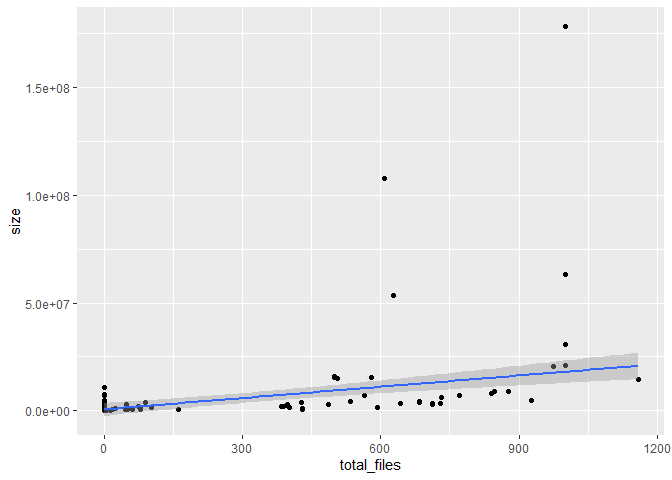

```r
df %>%
  ggplot(aes(y = size, x = total_files)) +
  geom_point() +
  geom_smooth(method = "lm")
```

The hypothesis is not met, the size don’t have a good correlarion with the number of files.

### Correlarion between positives and money permission

```r
lm_positives <-
  lm(positives ~ additional_info.androguard.RiskIndicator.PERM.MONEY, data = df)
```

```r
summary(lm_positives)
```

```
##
## Call:
## lm(formula = positives ~ additional_info.androguard.RiskIndicator.PERM.MONEY,
##     data = df)
##
## Residuals:
##     Min      1Q  Median      3Q     Max
## -7.7574 -3.5732 -0.5732  2.4268 13.2426
##
## Coefficients:
##                                                     Estimate Std. Error t value
## (Intercept)                                          20.5732     0.3595  57.233
## additional_info.androguard.RiskIndicator.PERM.MONEY   2.1842     0.3944   5.538
##                                                     Pr(>|t|)
## (Intercept)                                          < 2e-16 ***
## additional_info.androguard.RiskIndicator.PERM.MONEY 1.07e-07 ***
## ---
## Signif. codes:  0 '***' 0.001 '**' 0.01 '*' 0.05 '.' 0.1 ' ' 1
##
## Residual standard error: 4.234 on 181 degrees of freedom
## Multiple R-squared:  0.1449, Adjusted R-squared:  0.1402
## F-statistic: 30.67 on 1 and 181 DF,  p-value: 1.065e-07
```

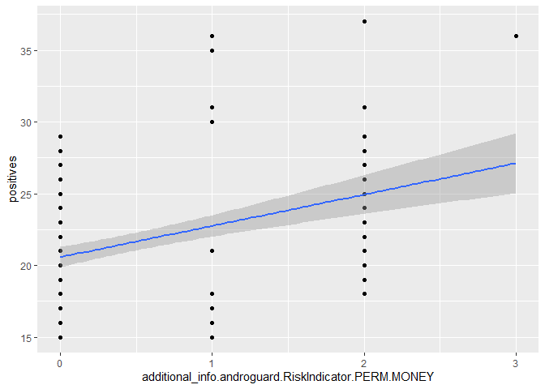

```r
df %>%
  ggplot(aes(
    y = positives,
    x = additional_info.androguard.RiskIndicator.PERM.MONEY)) +
  geom_point() +
  geom_smooth(method = "lm")
```

The hypothesis is not met, the positives don’t have a good correlarion with money permission.

## Conclusions

The only valuable conclusion is that the algorithm works well.

The correlations make sense but most of the correlations happen because of there are many NAs and therefore few real data.